```r
options(OutDec = ".")  # Asegurar punto decimal en este chunk

# Función para generar datos aleatorios del problema
generar_datos <- function() {
  # Generar pendiente aleatoria (entre -3 y 3, evitando 0)
  pendientes_posibles <- c(-3, -2.5, -2, -1.5, -1, -0.5, 0.5, 1, 1.5, 2, 2.5, 3)
  m <- sample(pendientes_posibles, 1)

  # Generar intercepto aleatorio (entre -4 y 4)
  b <- sample(seq(-4, 4, by = 0.5), 1)

  # Asegurar que la recta sea visible en el rango [-5, 5] x [-5, 5]
  # Calcular puntos de intersección con los bordes del gráfico
  x_min <- -5
  x_max <- 5
  y_min <- -5
  y_max <- 5

  # Encontrar dos puntos visibles en el gráfico
  puntos_visibles <- list()

  # Punto 1: intersección con borde izquierdo o derecho
  if (m != 0) {
    y_en_x_min <- m * x_min + b
    y_en_x_max <- m * x_max + b

    if (y_en_x_min >= y_min && y_en_x_min <= y_max) {
      puntos_visibles[[1]] <- c(x_min, y_en_x_min)
    } else if (y_en_x_max >= y_min && y_en_x_max <= y_max) {
      puntos_visibles[[1]] <- c(x_max, y_en_x_max)
    } else {
      # Usar intersección con borde superior o inferior
      x_en_y_min <- (y_min - b) / m
      x_en_y_max <- (y_max - b) / m
      if (x_en_y_min >= x_min && x_en_y_min <= x_max) {
        puntos_visibles[[1]] <- c(x_en_y_min, y_min)
      } else {
        puntos_visibles[[1]] <- c(x_en_y_max, y_max)
      }
    }

    # Punto 2: otro punto visible
    if (length(puntos_visibles) == 1) {
      x_test <- sample(seq(x_min, x_max, by = 1), 1)
      y_test <- m * x_test + b
      if (y_test >= y_min && y_test <= y_max) {
        puntos_visibles[[2]] <- c(x_test, y_test)
      } else {
        # Usar otro punto de borde
        x_test2 <- sample(seq(x_min, x_max, by = 1), 1)
        y_test2 <- m * x_test2 + b
        if (y_test2 >= y_min && y_test2 <= y_max) {
          puntos_visibles[[2]] <- c(x_test2, y_test2)
        } else {
          puntos_visibles[[2]] <- c(x_max, m * x_max + b)
        }
      }
    }
  } else {
    # Recta horizontal
    puntos_visibles[[1]] <- c(x_min, b)
    puntos_visibles[[2]] <- c(x_max, b)
  }

  # Formatear pendiente e intercepto para mostrar
  m_formateado <- ifelse(m == as.integer(m), as.character(m),
                        ifelse(abs(m) == 0.5, ifelse(m < 0, "-\\frac{1}{2}", "\\frac{1}{2}"),
                               ifelse(abs(m) == 1.5, ifelse(m < 0, "-\\frac{3}{2}", "\\frac{3}{2}"),
                                      ifelse(abs(m) == 2.5, ifelse(m < 0, "-\\frac{5}{2}", "\\frac{5}{2}"),
                                             sprintf("%.1f", m)))))

  b_formateado <- ifelse(b == as.integer(b), as.character(b), sprintf("%.1f", b))

  # Generar ecuación de la recta
  if (b == 0) {
    ecuacion <- paste0("y = ", m_formateado, "x")
  } else if (b > 0) {
    ecuacion <- paste0("y = ", m_formateado, "x + ", b_formateado)
  } else {
    # Usar abs() sobre el valor numérico, no sobre el string formateado
    b_abs_formateado <- ifelse(abs(b) == as.integer(abs(b)),
                               as.character(abs(b)),
                               sprintf("%.1f", abs(b)))
    ecuacion <- paste0("y = ", m_formateado, "x - ", b_abs_formateado)
  }

  # Generar opciones de respuesta (distractores pedagógicamente efectivos)
  # Opción correcta: la ecuación completa
  opcion_correcta <- ecuacion

  # Distractor 1: Pendiente correcta pero intercepto incorrecto
  b_distractor1 <- sample(c(b + 1, b - 1, b + 2, b - 2), 1)
  b_dist1_formateado <- ifelse(b_distractor1 == as.integer(b_distractor1),
                               as.character(b_distractor1),
                               sprintf("%.1f", b_distractor1))
  if (b_distractor1 == 0) {
    distractor1 <- paste0("y = ", m_formateado, "x")
  } else if (b_distractor1 > 0) {
    distractor1 <- paste0("y = ", m_formateado, "x + ", b_dist1_formateado)
  } else {
    # Usar abs() sobre el valor numérico, no sobre el string formateado
    b_dist1_abs_formateado <- ifelse(abs(b_distractor1) == as.integer(abs(b_distractor1)),
                                     as.character(abs(b_distractor1)),
                                     sprintf("%.1f", abs(b_distractor1)))
    distractor1 <- paste0("y = ", m_formateado, "x - ", b_dist1_abs_formateado)
  }

  # Distractor 2: Intercepto correcto pero pendiente incorrecta
  m_distractor2 <- sample(pendientes_posibles[pendientes_posibles != m], 1)
  m_dist2_formateado <- ifelse(m_distractor2 == as.integer(m_distractor2),
                               as.character(m_distractor2),
                               ifelse(abs(m_distractor2) == 0.5,
                                      ifelse(m_distractor2 < 0, "-\\frac{1}{2}", "\\frac{1}{2}"),
                                      ifelse(abs(m_distractor2) == 1.5,
                                             ifelse(m_distractor2 < 0, "-\\frac{3}{2}", "\\frac{3}{2}"),
                                             ifelse(abs(m_distractor2) == 2.5,
                                                    ifelse(m_distractor2 < 0, "-\\frac{5}{2}", "\\frac{5}{2}"),
                                                    sprintf("%.1f", m_distractor2)))))
  if (b == 0) {
    distractor2 <- paste0("y = ", m_dist2_formateado, "x")
  } else if (b > 0) {
    distractor2 <- paste0("y = ", m_dist2_formateado, "x + ", b_formateado)
  } else {
    # Usar abs() sobre el valor numérico, no sobre el string formateado
    b_abs_formateado <- ifelse(abs(b) == as.integer(abs(b)),
                               as.character(abs(b)),
                               sprintf("%.1f", abs(b)))
    distractor2 <- paste0("y = ", m_dist2_formateado, "x - ", b_abs_formateado)
  }

  # Distractor 3: Ambos incorrectos pero con valores cercanos
  m_distractor3 <- sample(pendientes_posibles[pendientes_posibles != m & pendientes_posibles != m_distractor2], 1)
  b_distractor3 <- sample(c(b + 1, b - 1, b + 2, b - 2), 1)
  m_dist3_formateado <- ifelse(m_distractor3 == as.integer(m_distractor3),
                               as.character(m_distractor3),
                               ifelse(abs(m_distractor3) == 0.5,
                                      ifelse(m_distractor3 < 0, "-\\frac{1}{2}", "\\frac{1}{2}"),
                                      ifelse(abs(m_distractor3) == 1.5,
                                             ifelse(m_distractor3 < 0, "-\\frac{3}{2}", "\\frac{3}{2}"),
                                             ifelse(abs(m_distractor3) == 2.5,
                                                    ifelse(m_distractor3 < 0, "-\\frac{5}{2}", "\\frac{5}{2}"),
                                                    sprintf("%.1f", m_distractor3)))))
  b_dist3_formateado <- ifelse(b_distractor3 == as.integer(b_distractor3),
                               as.character(b_distractor3),
                               sprintf("%.1f", b_distractor3))
  if (b_distractor3 == 0) {
    distractor3 <- paste0("y = ", m_dist3_formateado, "x")
  } else if (b_distractor3 > 0) {
    distractor3 <- paste0("y = ", m_dist3_formateado, "x + ", b_dist3_formateado)
  } else {
    # Usar abs() sobre el valor numérico, no sobre el string formateado
    b_dist3_abs_formateado <- ifelse(abs(b_distractor3) == as.integer(abs(b_distractor3)),
                                     as.character(abs(b_distractor3)),
                                     sprintf("%.1f", abs(b_distractor3)))
    distractor3 <- paste0("y = ", m_dist3_formateado, "x - ", b_dist3_abs_formateado)
  }

  # Mezclar opciones
  todas_opciones <- c(opcion_correcta, distractor1, distractor2, distractor3)
  orden_opciones <- sample(1:4)
  opciones_mezcladas <- todas_opciones[orden_opciones]
  posicion_correcta <- which(orden_opciones == 1)

  return(list(
    m = m,
    b = b,
    m_formateado = m_formateado,
    b_formateado = b_formateado,
    ecuacion = ecuacion,
    puntos_visibles = puntos_visibles,
    opciones = opciones_mezcladas,
    respuesta_correcta = opcion_correcta,
    posicion_correcta = posicion_correcta
  ))
}

# Generar datos para este ejercicio
datos <- generar_datos()
```

```r
# Crear gráfico de la recta usando TikZ
# Calcular puntos para dibujar la recta en el rango visible
x_min <- -5
x_max <- 5
y_min <- -5
y_max <- 5

# Calcular puntos de intersección de la recta con los bordes del gráfico
puntos_interseccion <- list()

# Intersección con borde izquierdo (x = -5)
y_izq <- datos$m * x_min + datos$b
if (y_izq >= y_min && y_izq <= y_max) {
  puntos_interseccion[[length(puntos_interseccion) + 1]] <- c(x_min, y_izq)
}

# Intersección con borde derecho (x = 5)
y_der <- datos$m * x_max + datos$b
if (y_der >= y_min && y_der <= y_max) {
  puntos_interseccion[[length(puntos_interseccion) + 1]] <- c(x_max, y_der)
}

# Intersección con borde inferior (y = -5)
if (datos$m != 0) {
  x_inf <- (y_min - datos$b) / datos$m
  if (x_inf >= x_min && x_inf <= x_max && !any(sapply(puntos_interseccion, function(p) abs(p[1] - x_inf) < 0.1))) {
    puntos_interseccion[[length(puntos_interseccion) + 1]] <- c(x_inf, y_min)
  }

  # Intersección con borde superior (y = 5)
  x_sup <- (y_max - datos$b) / datos$m
  if (x_sup >= x_min && x_sup <= x_max && !any(sapply(puntos_interseccion, function(p) abs(p[1] - x_sup) < 0.1))) {
    puntos_interseccion[[length(puntos_interseccion) + 1]] <- c(x_sup, y_max)
  }
}

# Asegurar que tenemos al menos 2 puntos
if (length(puntos_interseccion) < 2) {
  # Si solo tenemos un punto, usar puntos adicionales
  x1 <- x_min
  y1 <- datos$m * x1 + datos$b
  x2 <- x_max
  y2 <- datos$m * x2 + datos$b
  puntos_interseccion <- list(c(x1, y1), c(x2, y2))
}

# Tomar los primeros 2 puntos para dibujar la recta
p1 <- puntos_interseccion[[1]]
p2 <- puntos_interseccion[[2]]

# Construir código para marcar el intercepto si es visible
codigo_intercepto <- ""
if (datos$b >= y_min && datos$b <= y_max) {
  codigo_intercepto <- paste0("  % Marcar el intercepto en y\n",
                               "  \\draw[red, fill=red] (0, ", datos$b, ") circle (2pt);\n",
                               "  \\node[right, red] at (0.3, ", datos$b, ") {$(0, ", datos$b_formateado, ")$};\n")
}

# Crear código TikZ para el gráfico
grafico_recta <- paste0("
\\begin{tikzpicture}[scale=0.8]
  % Dibujar ejes
  \\draw[->, thick] (-5.5, 0) -- (5.5, 0) node[right] {$x$};
  \\draw[->, thick] (0, -5.5) -- (0, 5.5) node[above] {$y$};

  % Etiquetas en los ejes
  \\foreach \\x in {-5, -4, -3, -2, -1, 1, 2, 3, 4, 5}
    \\draw (\\x, 0.1) -- (\\x, -0.1) node[below] {\\x};
  \\foreach \\y in {-5, -4, -3, -2, -1, 1, 2, 3, 4, 5}
    \\draw (0.1, \\y) -- (-0.1, \\y) node[left] {\\y};

  % Origen
  \\node[below left] at (0, 0) {0};

  % Dibujar la recta
  \\draw[blue, very thick] (", p1[1], ", ", p1[2], ") -- (", p2[1], ", ", p2[2], ");

", codigo_intercepto, "
  % Marcar puntos en la recta para facilitar la lectura
  \\draw[blue, fill=blue] (", p1[1], ", ", p1[2], ") circle (2pt);
  \\draw[blue, fill=blue] (", p2[1], ", ", p2[2], ") circle (2pt);
\\end{tikzpicture}
")
```

# Question

En el siguiente gráfico se muestra una recta en el plano cartesiano:

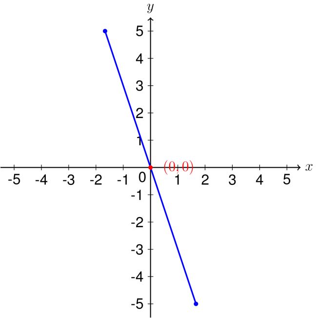

¿Cuál es la ecuación de la recta representada en el gráfico?

## Answerlist

- y = 1x + 1
- y = 3x
- y = -3x + 1
- y = -3x

# Solution

Para determinar la ecuación de la recta, necesitamos identificar su pendiente ($m$) y su intercepto con el eje $y$ ($b$).

La ecuación de una recta tiene la forma:
$$y = mx + b$$

donde: - $m$ es la pendiente de la recta - $b$ es el intercepto con el eje $y$ (el valor de $y$ cuando $x = 0$)

**Análisis del gráfico:**

1. **Intercepto con el eje $y$**: Observando el gráfico, la recta intersecta el eje $y$ en el punto $(0, 0)$. Por lo tanto, $b = 0$.
2. **Pendiente**: La pendiente se puede calcular usando dos puntos de la recta. Observando el gráfico:
   - La recta pasa por el punto $(0, 0)$
   - Para calcular la pendiente, podemos usar otro punto visible en la recta

   La pendiente es $m = -3$.

**Ecuación de la recta:**

Sustituyendo los valores encontrados:
$$y
= -3x + 0$$

Por lo tanto, la ecuación de la recta es: **$y = -3x$**

## Answerlist

- Incorrecto. No corresponde a la ecuación de la recta mostrada en el gráfico.
- Incorrecto. Error en la identificación del intercepto o la pendiente.
- Incorrecto. Error en la identificación del intercepto o la pendiente.
- Correcto. Identifica correctamente la ecuación de la recta analizando la pendiente y el intercepto en el gráfico.

# Meta-information

exname: recta_geometria_analitica_interpretacion_representacion extype: schoice exsolution: 0001 exshuffle: TRUE exsection: Geometría/Geometría Analítica/Ecuación de la recta